# class_08

Claudia Medrano

10/25/2019

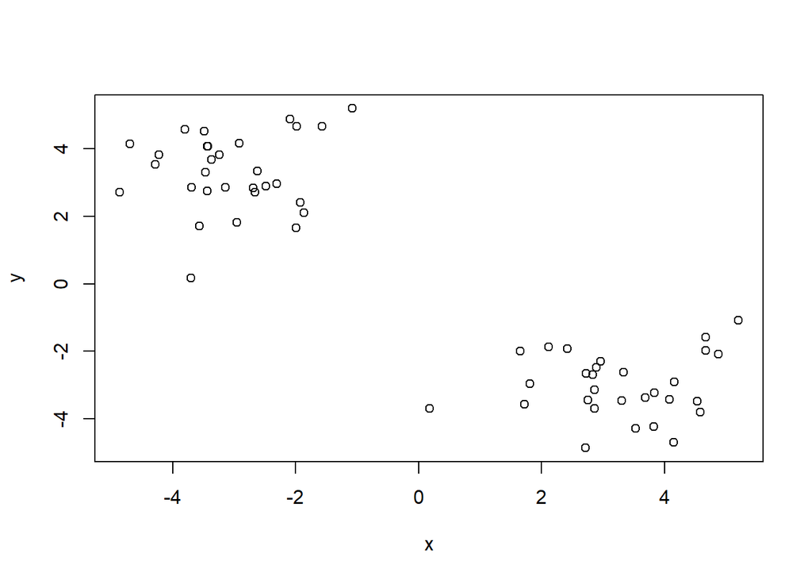

```r
# Generate some example data for clustering
tmp <- c(rnorm(30,-3), rnorm(30,3))
x <- cbind(x=tmp, y=rev(tmp))

plot(x)
```

Use the kmeans() function setting k to 2 and nstart=20

```r
k <-  kmeans(x, centers = 2, nstart = 20)
```

Inspect/print the results

```r
k
```

```
## K-means clustering with 2 clusters of sizes 30, 30
##
## Cluster means:
##           x         y
## 1 -3.030708  3.297627
## 2  3.297627 -3.030708
##
## Clustering vector:
##  [1] 1 1 1 1 1 1 1 1 1 1 1 1 1 1 1 1 1 1 1 1 1 1 1 1 1 1 1 1 1 1 2 2 2 2 2
## [36] 2 2 2 2 2 2 2 2 2 2 2 2 2 2 2 2 2 2 2 2 2 2 2 2 2
##
## Within cluster sum of squares by cluster:
## [1] 62.33621 62.33621
##  (between_SS / total_SS =  90.6 %)
##
## Available components:
##
## [1] "cluster"      "centers"      "totss"        "withinss"
## [5] "tot.withinss" "betweenss"    "size"         "iter"
## [9] "ifault"
```

Q. How many points are in each cluster?

```r
k$size
```

```
## [1] 30 30
```

Q. What ‘component’ of your result object details - cluster size? size - cluster assignment/membership?

```r
k$cluster
```

```
##  [1] 1 1 1 1 1 1 1 1 1 1 1 1 1 1 1 1 1 1 1 1 1 1 1 1 1 1 1 1 1 1 2 2 2 2 2
## [36] 2 2 2 2 2 2 2 2 2 2 2 2 2 2 2 2 2 2 2 2 2 2 2 2 2
```

```r
table(k$cluster)
```

```
##
##  1  2
## 30 30
```

- cluster center?

Plot x colored by the kmeans cluster assignment and add cluster centers as blue points

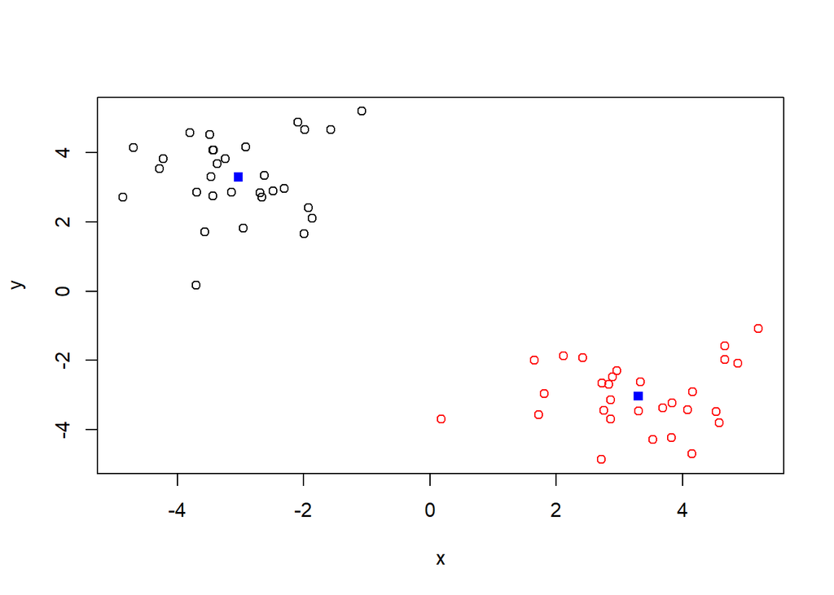

```r
plot(x, col = k$cluster)
points(k$centers, col="blue", pch = 15)
```

##Hierarchical clustering in R Call: hclust(d = dist_matrix) Cluster method : complete Distance : euclidean Number of objects: 60

```r
hc <- hclust(dist(x))
```

plot my results

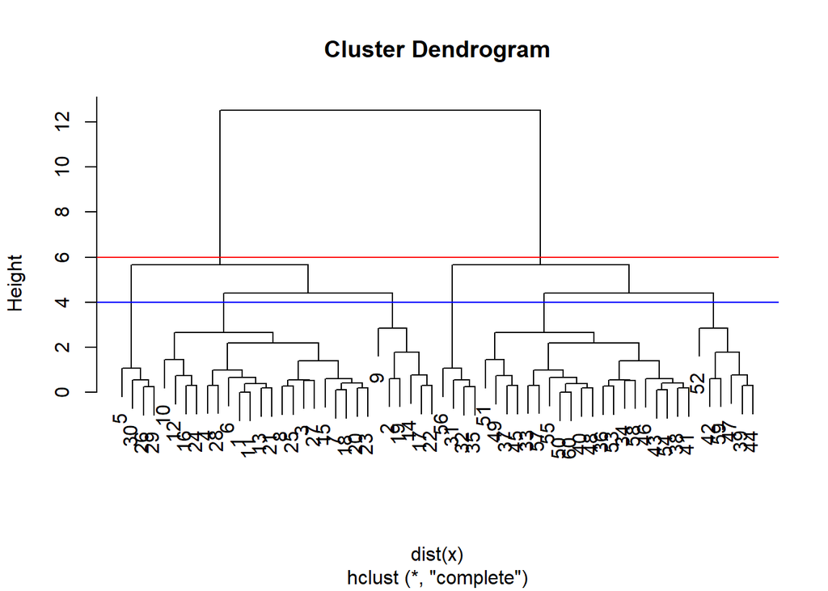

```r
plot(hc)
#draws the red line at specified height
abline(h=6,col="red")
abline(h=4,col="blue")
```

```r
cutree(hc, h=6)
```

```
##  [1] 1 1 1 1 1 1 1 1 1 1 1 1 1 1 1 1 1 1 1 1 1 1 1 1 1 1 1 1 1 1 2 2 2 2 2
## [36] 2 2 2 2 2 2 2 2 2 2 2 2 2 2 2 2 2 2 2 2 2 2 2 2 2
```

```r
grps <- cutree(hc, h=4)
table(grps)
```

```
## grps
##  1  2  3  4  5  6
## 20  6  4  4 20  6
```

I can also cut the tree to yield a given ‘k’ groups/clusters

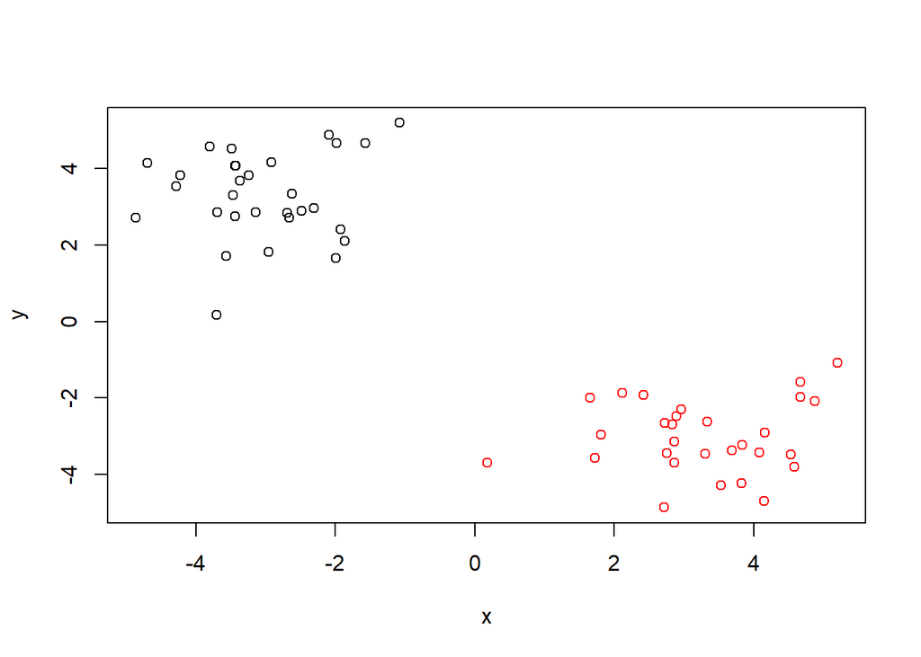

```r
grps <- cutree(hc, k=2)
plot(x, col=grps)
```

##Another cluster example Here we have some more realistic

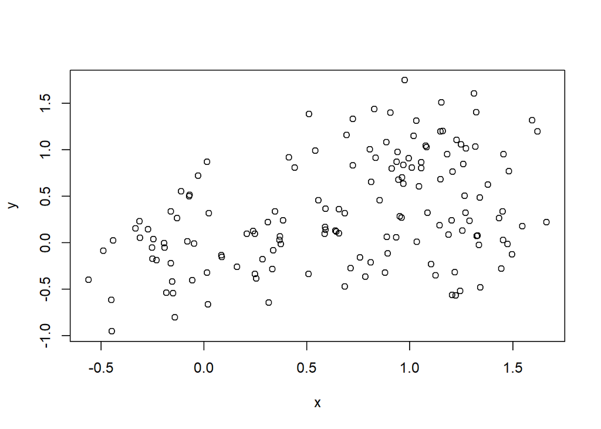

```r
# Step 1. Generate some example data for clustering
x <- rbind(
 matrix(rnorm(100, mean=0, sd = 0.3), ncol = 2),
 matrix(rnorm(100, mean = 1, sd = 0.3), ncol = 2),
 matrix(c(rnorm(50, mean = 1, sd = 0.3),
 rnorm(50, mean = 0, sd = 0.3)), ncol = 2))
colnames(x) <- c("x", "y")
# Step 2. Plot the data without clustering
plot(x)
```

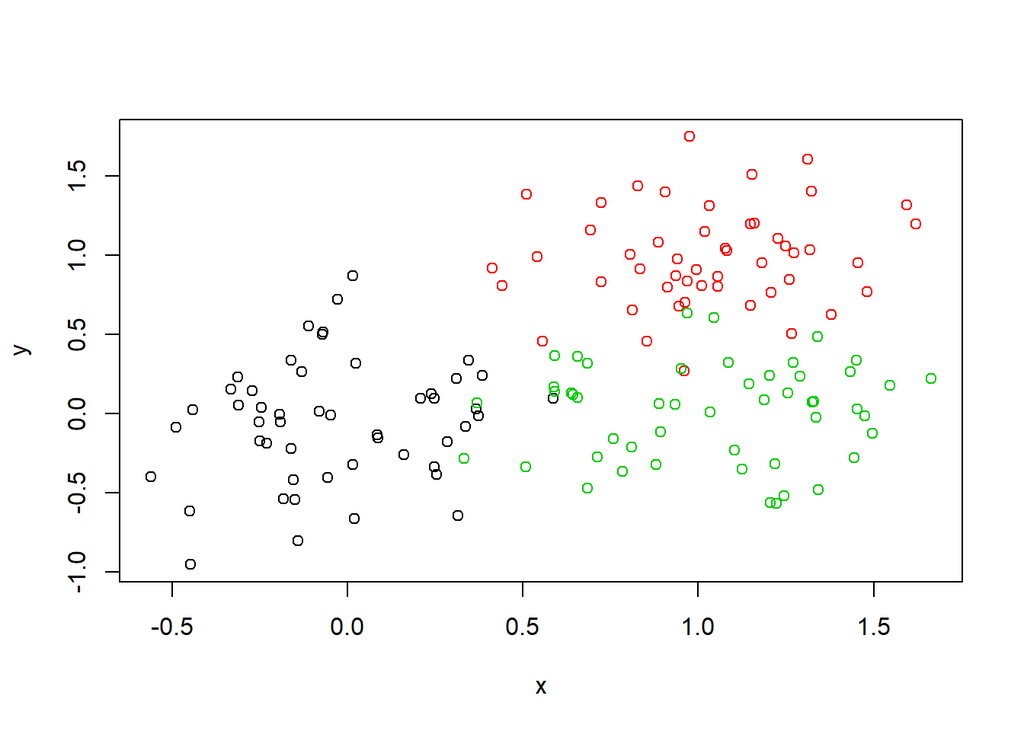

```r
# Step 3. Generate colors for known clusters
# (just so we can compare to hclust results)
col <- as.factor( rep(c("c1","c2","c3"), each=50) )
plot(x, col=col)
```

Use the dist(), hclust(), plot() and

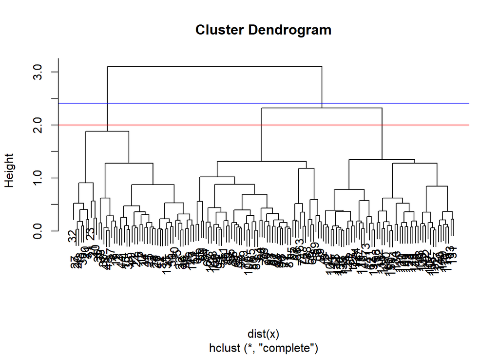

```r
grps <- hclust(dist(x))
plot(grps)
abline(h=2.4,col="blue")
abline(h=2, col="red")
```

cutree() functions to return 2 and 3 clusters

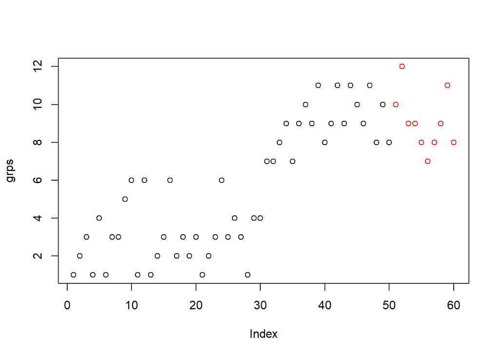

```r
grps <- cutree(hc,h=1.8)
plot(grps,col=col)
```

Q. How does this compare to your known ‘col’ groups?

##Hands on PCA

```r
mydata <- read.csv("https://tinyurl.com/expression-CSV",
 row.names=1)

head(mydata)
```

```
##        wt1 wt2  wt3  wt4 wt5 ko1 ko2 ko3 ko4 ko5
## gene1  439 458  408  429 420  90  88  86  90  93
## gene2  219 200  204  210 187 427 423 434 433 426
## gene3 1006 989 1030 1017 973 252 237 238 226 210
## gene4  783 792  829  856 760 849 856 835 885 894
## gene5  181 249  204  244 225 277 305 272 270 279
## gene6  460 502  491  491 493 612 594 577 618 638
```

call prcomp on data set. we need to take the ‘t()’ of our data

```r
pca <- prcomp(t(mydata), scale=TRUE)
attributes(pca)
```

```
## $names
## [1] "sdev"     "rotation" "center"   "scale"    "x"
##
## $class
## [1] "prcomp"
```

```r
nrow(mydata)
```

```
## [1] 100
```

```r
ncol(mydata)
```

```
## [1] 10
```

```r
pca$x
```

```
##           PC1        PC2        PC3        PC4        PC5        PC6
## wt1 -9.697374  1.5233313 -0.2753567  0.7322391 -0.6749398 -1.1823860
## wt2 -9.138950  0.3748504  1.0867958 -1.9461655  0.7571209  0.4369228
## wt3 -9.054263 -0.9855163  0.4152966  1.4166028  0.5835918 -0.6937236
## wt4 -8.731483 -0.7468371  0.5875748  0.2268129 -1.5404775  1.2723618
## wt5 -9.006312 -0.2945307 -1.8498101 -0.4303812  0.8666124  0.2496025
## ko1  8.846999  2.2345475 -0.1462750 -1.1544333 -0.6947862 -0.7128021
## ko2  9.213885 -3.2607503  0.2287292 -0.7658122 -0.4922849 -0.9170241
## ko3  9.458412 -0.2636283 -1.5778183  0.2433549  0.3654124  0.5837724
## ko4  8.883412  0.6339701  1.5205064  0.7760158  1.2158376  0.1446094
## ko5  9.225673  0.7845635  0.0103574  0.9017667 -0.3860869  0.8186668
##             PC7         PC8         PC9         PC10
## wt1  0.24446614  1.03519396  0.07010231 3.691492e-15
## wt2  0.03275370  0.26622249  0.72780448 3.080869e-15
## wt3  0.03578383 -1.05851494  0.52979799 2.595146e-15
## wt4  0.52795595 -0.20995085 -0.50325679 3.122502e-15
## wt5 -0.83227047 -0.05891489 -0.81258430 3.302913e-15
## ko1  0.07864392 -0.94652648 -0.24613776 3.351486e-15
## ko2 -0.30945771  0.33231138 -0.08786782 2.629841e-15
## ko3  1.43723425  0.14495188  0.56617746 3.094747e-15
## ko4  0.35073859  0.30381920 -0.87353886 2.983724e-15
## ko5 -1.56584821  0.19140827  0.62950330 3.233525e-15
```

plot PCA1 vs PCA2

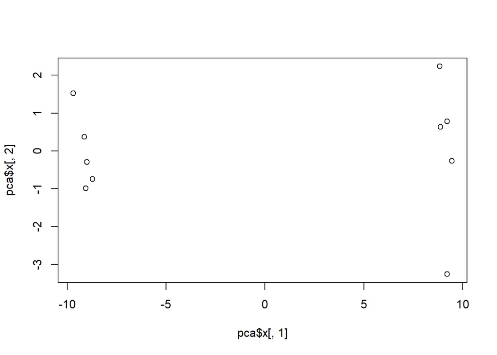

```r
plot(pca$x[,1], pca$x[,2])
```

```r
summary(pca)
```

```
## Importance of components:
##                           PC1    PC2     PC3     PC4     PC5     PC6
## Standard deviation     9.6237 1.5198 1.05787 1.05203 0.88062 0.82545
## Proportion of Variance 0.9262 0.0231 0.01119 0.01107 0.00775 0.00681
## Cumulative Proportion  0.9262 0.9493 0.96045 0.97152 0.97928 0.98609
##                            PC7     PC8     PC9      PC10
## Standard deviation     0.80111 0.62065 0.60342 3.348e-15
## Proportion of Variance 0.00642 0.00385 0.00364 0.000e+00
## Cumulative Proportion  0.99251 0.99636 1.00000 1.000e+00
```

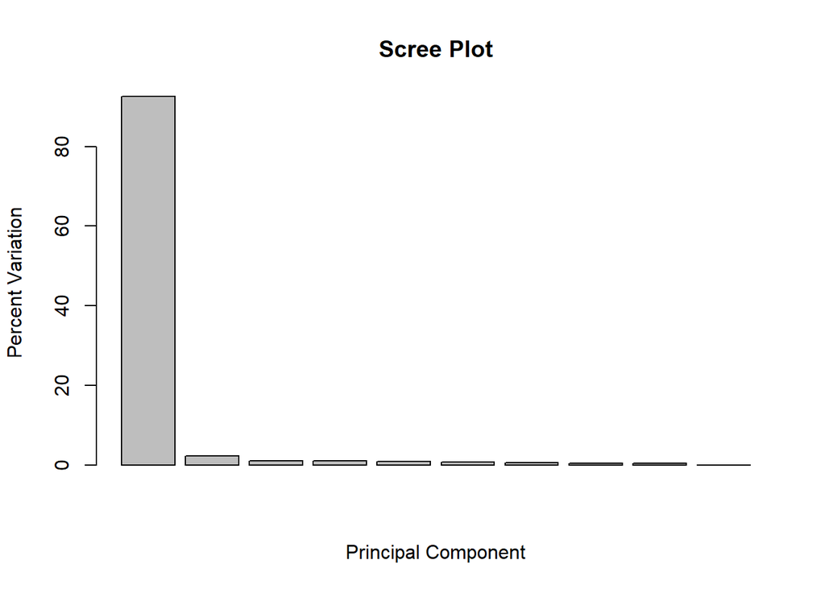

```r
pca.var <- pca$sdev^2
pca.var.per <- round(pca.var/sum(pca.var)*100, 1)

barplot(pca.var.per, main="Scree Plot",
 xlab="Principal Component", ylab="Percent Variation")
```

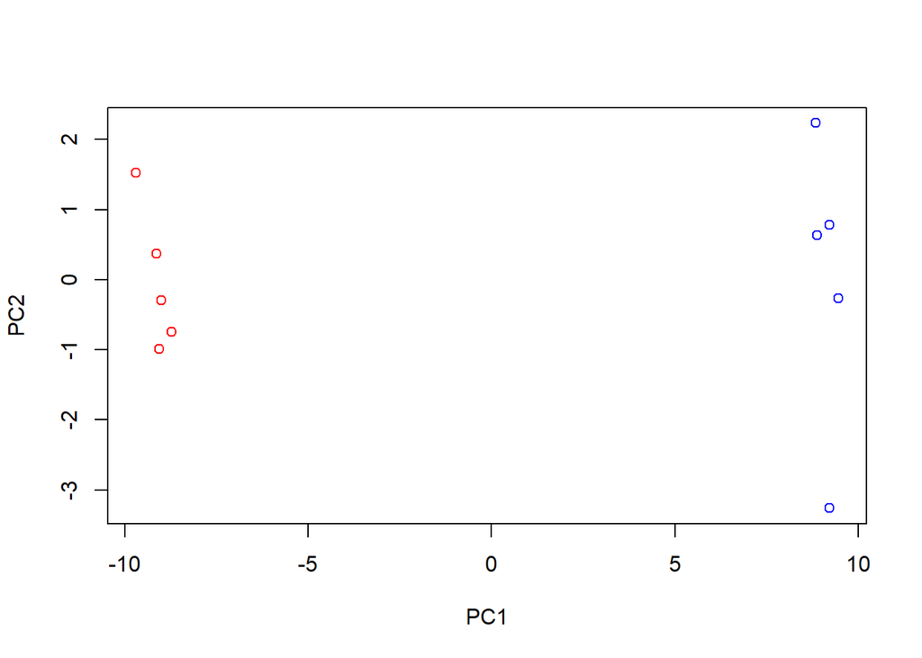

```r
plot(pca$x[,1:2], col=c("red", "red", "red", "red", "red", "blue", "blue", "blue", "blue", "blue"))
```

##Perform a PCA on the UK foods dataset

```r
x <- read.csv(file = "data/UK_foods.csv")
```

Q1. How many rows and columns are in your new data frame named x? What R functions could you use to answer this questions?

```r
ncol(x)
```

```
## [1] 5
```

```r
nrow(x)
```

```
## [1] 17
```

Preview the first 6 rows

```r
head(x)
```

```
##                X England Wales Scotland N.Ireland
## 1         Cheese     105   103      103        66
## 2  Carcass_meat      245   227      242       267
## 3    Other_meat      685   803      750       586
## 4           Fish     147   160      122        93
## 5 Fats_and_oils      193   235      184       209
## 6         Sugars     156   175      147       139
```